# Regression: Extension exercises

Ben Whalley

September 2020

### Extension exercises

If you have time, try to answer the following questions based on other datasets built into R.

Using the `mtcars` data (which is built into R):

- What do you predict the `mpg` would be for a car with 4 cylinders?
- What is the difference in `mpg` between a car with 4 and 5 cylinders?
- Is your prediction for a car with 4 cylinders the same as the *mean* mpg for cars with 4 cylinders? Can you explain why/why not?
- Run a model using `wt` to predict `mpg`
- Using `augment` with the `newdata` argument, make a ggplot (using `geom_smooth`) showing the prediction for all weight values between 1 and 6.

```r
m1 <- lm(mpg ~ cyl, data=mtcars)
predict(m1, newdata=tibble(cyl=4))
```

```
##        1
## 26.38142
```

Calculate predictions for 4 and 5 cyl cars and then the difference (you might have done this by hand):

```r
(fourandfvecylcars <- predict(m1, newdata=tibble(cyl=c(4,5))))
```

```
##        1        2
## 26.38142 23.50563
```

```r
diff(fourandfvecylcars) # this shows the difference
```

```
##        2
## -2.87579
```

The prediction and the mean for 4 cylinder cars is not quite the same:

```r
predict(m1, newdata=tibble(cyl=4))
```

```
##        1
## 26.38142
```

```r
mtcars %>% filter(cyl==4) %>% summarise(mean(mpg))
```

```
##   mean(mpg)
## 1  26.66364
```

The reason is that the prediction comes from the *regression line*… the line of best fit. Although in this case they are close it won’t always match the mean exactly.

This shows the new model using `wt` as a predictor. Then we use augment to make new predictions and plot them:

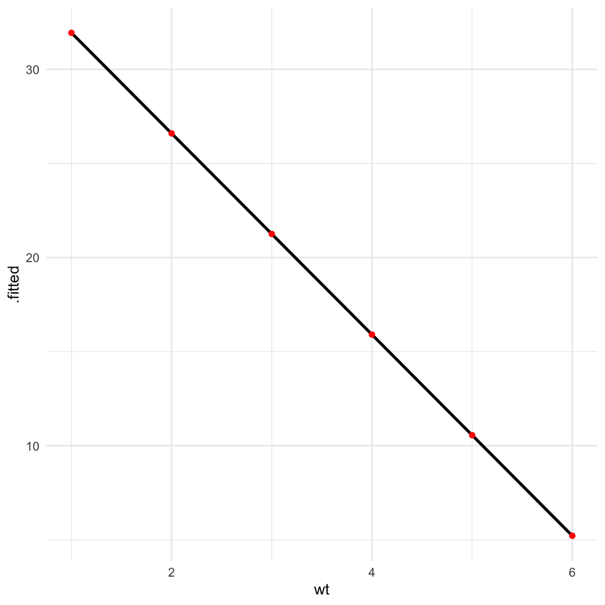

```r
m2 <- lm(mpg~wt, mtcars)
broom::augment(m2, newdata=tibble(wt=c(1,2,3,4,5,6))) %>%
  ggplot(aes(wt, .fitted)) +
  geom_smooth(color="black") +
  geom_point(color="red")
```

Using the `iris` dataset which is also built into R:

- What is your prediction for `Sepal.Length` for specimens which are 2 or 4mm wide?
- What is your prediction for a specimen which was 8mm wide? How confident are you about this prediction?

```r
library(broom)
lm(mpg~cyl, data=mtcars)  %>%
  augment(newdata=tibble(cyl=c(3,4,5,6)))
```

```
## # A tibble: 4 x 3
##     cyl .fitted .se.fit
##   <dbl>   <dbl>   <dbl>
## 1     3    29.3   1.17
## 2     4    26.4   0.905
## 3     5    23.5   0.684
## 4     6    20.6   0.570
```

```r
lm(Sepal.Length~Sepal.Width, data=iris) %>%
  augment(newdata=tibble(Sepal.Width=c(2,4)))
```

```
## # A tibble: 2 x 3
##   Sepal.Width .fitted .se.fit
##         <dbl>   <dbl>   <dbl>
## 1           2    6.08   0.177
## 2           4    5.63   0.161
```

- Is hours a good predictor of income in this dataset?
- What is your predicted income for someone who works 40 hours per week?

Prediction for 40 hours:

```r
cps<- read_csv('http://www.willslab.org.uk/cps2.csv')
lm(income~hours, data=cps) %>%
  augment(newdata=tibble(hours=40))
```

```
## # A tibble: 1 x 3
##   hours .fitted .se.fit
##   <dbl>   <dbl>   <dbl>
## 1    40 103410.   2063.
```

Return to the index page

All content on this site distributed under a [Creative Commons](https://creativecommons.org/) licence. CC-BY-SA 4.0.